# M3T4

Saleh Precious

2023-04-13

```r
library(ggplot2)
```

```r
library(readr)
```

```r
library(arules)
```

```r
library(arulesViz)
```

```r
library(tidyverse)
library(knitr)
library(gridExtra)
library(lubridate)
library(RColorBrewer)
```

```r
Electronidex<-read.transactions("ElectronidexTransactions2017.csv",sep = ",")
```

```r
Electronidex
```

```
## transactions in sparse format with
##  9835 transactions (rows) and
##  125 items (columns)
```

```r
Electronidex %>% head(n=5) %>% inspect
```

```
##     items
## [1] {Acer Aspire,
##      Belkin Mouse Pad,
##      Brother Printer Toner,
##      VGA Monitor Cable}
## [2] {Apple Wireless Keyboard,
##      Dell Desktop,
##      Lenovo Desktop Computer}
## [3] {iMac}
## [4] {Acer Desktop,
##      Intel Desktop,
##      Lenovo Desktop Computer,
##      XIBERIA Gaming Headset}
## [5] {ASUS Desktop,
##      Epson Black Ink,
##      HP Laptop,
##      iMac}
```

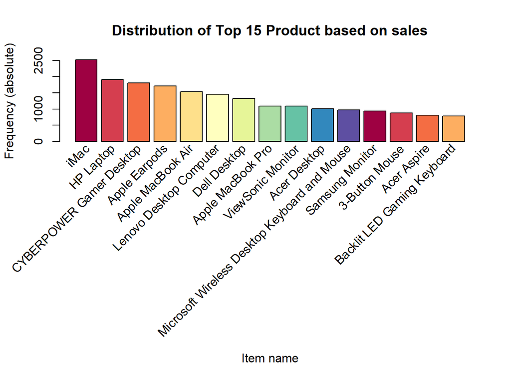

```r
itemFrequencyPlot(Electronidex,topN=15, type="absolute", col=brewer.pal(15,'Spectral'),xlab="Item name",
                  ylab="Frequency (absolute)", main="Distribution of Top 15 Product based on sales")
```

#From the distribution above, we can see that the top selling product of Electronidex is the iMac which falls under the desktop category #we can also see that the top three selling products falls under the Desktop and Laptop product types. #RULES

```r
Rules_sup1<- apriori (Electronidex, parameter = list(supp = 0.002, conf = 0.8),minlen=2)
```

```
## Apriori
##
## Parameter specification:
##  confidence minval smax arem  aval originalSupport maxtime support minlen
##         0.8    0.1    1 none FALSE            TRUE       5   0.002      2
##  maxlen target  ext
##      10  rules TRUE
##
## Algorithmic control:
##  filter tree heap memopt load sort verbose
##     0.1 TRUE TRUE  FALSE TRUE    2    TRUE
##
## Absolute minimum support count: 19
##
## set item appearances ...[0 item(s)] done [0.00s].
## set transactions ...[125 item(s), 9835 transaction(s)] done [0.00s].
## sorting and recoding items ... [125 item(s)] done [0.00s].
## creating transaction tree ... done [0.00s].
## checking subsets of size 1 2 3 4 5 6 done [0.00s].
## writing ... [28 rule(s)] done [0.00s].
## creating S4 object  ... done [0.00s].
```

```r
inspect(Rules_sup1)
```

```
##      lhs                                                   rhs                     support confidence    coverage     lift count
## [1]  {Logitech Desktop MK120 Mouse and keyboard Combo,
##       ViewSonic Monitor}                                => {HP Laptop}         0.002033554  0.8000000 0.002541942 4.121530    20
## [2]  {Dell Desktop,
##       Mackie CR Speakers}                               => {iMac}              0.002643620  0.8666667 0.003050330 3.383750    26
## [3]  {Dell KM117 Wireless Keyboard & Mouse,
##       iPhone Charger Cable}                             => {Apple MacBook Air} 0.002033554  0.9523810 0.002135231 6.122004    20
## [4]  {Dell Desktop,
##       HP Black & Tri-color Ink}                         => {iMac}              0.002541942  0.8064516 0.003152008 3.148651    25
## [5]  {CYBERPOWER Gamer Desktop,
##       HP Black & Tri-color Ink}                         => {iMac}              0.002440264  0.8000000 0.003050330 3.123462    24
## [6]  {ASUS Monitor,
##       Computer Game,
##       ViewSonic Monitor}                                => {iMac}              0.002033554  0.8000000 0.002541942 3.123462    20
## [7]  {Acer Aspire,
##       Computer Game,
##       ViewSonic Monitor}                                => {HP Laptop}         0.002033554  0.8333333 0.002440264 4.293260    20
## [8]  {Computer Game,
##       Dell Desktop,
##       ViewSonic Monitor}                                => {HP Laptop}         0.002643620  0.8666667 0.003050330 4.464990    26
## [9]  {Acer Aspire,
##       Epson Printer,
##       ViewSonic Monitor}                                => {HP Laptop}         0.002135231  0.8076923 0.002643620 4.161160    21
## [10] {ASUS Monitor,
##       HP Laptop,
##       LG Monitor}                                       => {iMac}              0.002236909  0.8461538 0.002643620 3.303661    22
## [11] {ASUS 2 Monitor,
##       ASUS Monitor,
##       Lenovo Desktop Computer}                          => {iMac}              0.002440264  0.8000000 0.003050330 3.123462    24
## [12] {ASUS 2 Monitor,
##       Dell Desktop,
##       Microsoft Office Home and Student 2016}           => {iMac}              0.002440264  0.8275862 0.002948653 3.231167    24
## [13] {Acer Desktop,
##       Apple Magic Keyboard,
##       ASUS Monitor}                                     => {iMac}              0.002236909  0.8461538 0.002643620 3.303661    22
## [14] {Apple Magic Keyboard,
##       Dell Desktop,
##       Microsoft Office Home and Student 2016}           => {iMac}              0.002440264  0.8275862 0.002948653 3.231167    24
## [15] {Acer Aspire,
##       Microsoft Office Home and Student 2016,
```

[output cut: 34 more lines]

```
##       Dell Desktop,
##       Lenovo Desktop Computer,
##       ViewSonic Monitor}                                => {HP Laptop}         0.002033554  0.8000000 0.002541942 4.121530    20
## [26] {Acer Aspire,
##       Dell Desktop,
##       iMac,
##       ViewSonic Monitor}                                => {HP Laptop}         0.003762074  0.9024390 0.004168785 4.649286    37
## [27] {Acer Aspire,
##       HP Laptop,
##       Lenovo Desktop Computer,
##       ViewSonic Monitor}                                => {iMac}              0.002440264  0.8000000 0.003050330 3.123462    24
## [28] {Acer Desktop,
##       Dell Desktop,
##       iMac,
##       ViewSonic Monitor}                                => {HP Laptop}         0.003253686  0.8000000 0.004067107 4.121530    32
```

```r
summary(Rules_sup1)
```

```
## set of 28 rules
##
## rule length distribution (lhs + rhs):sizes
##  3  4  5
##  5 14  9
##
##    Min. 1st Qu.  Median    Mean 3rd Qu.    Max.
##   3.000   4.000   4.000   4.143   5.000   5.000
##
## summary of quality measures:
##     support           confidence        coverage             lift
##  Min.   :0.002034   Min.   :0.8000   Min.   :0.002135   Min.   :3.123
##  1st Qu.:0.002034   1st Qu.:0.8000   1st Qu.:0.002542   1st Qu.:3.142
##  Median :0.002288   Median :0.8101   Median :0.002745   Median :3.344
##  Mean   :0.002448   Mean   :0.8253   Mean   :0.002967   Mean   :3.749
##  3rd Qu.:0.002440   3rd Qu.:0.8350   3rd Qu.:0.003050   3rd Qu.:4.197
##  Max.   :0.005287   Max.   :0.9524   Max.   :0.006507   Max.   :6.122
##      count
##  Min.   :20.00
##  1st Qu.:20.00
##  Median :22.50
##  Mean   :24.07
##  3rd Qu.:24.00
##  Max.   :52.00
##
## mining info:
##          data ntransactions support confidence
##  Electronidex          9835   0.002        0.8
##                                                                                  call
##  apriori(data = Electronidex, parameter = list(supp = 0.002, conf = 0.8), minlen = 2)
```

#visualize the rule

```
## To reduce overplotting, jitter is added! Use jitter = 0 to prevent jitter.
```

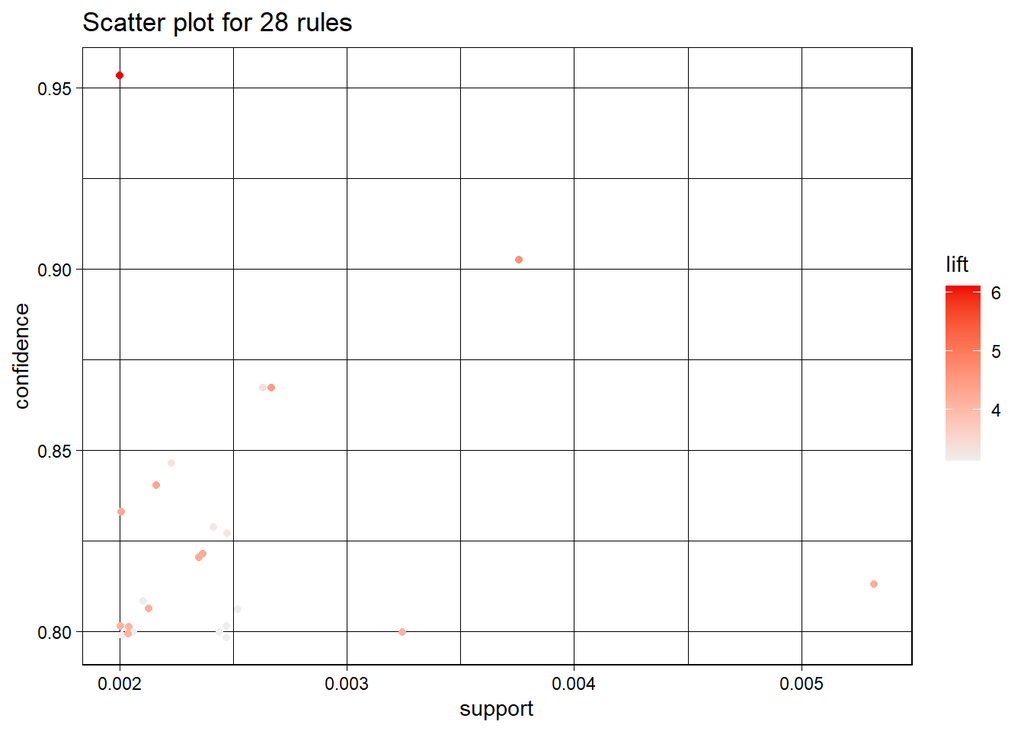

```r
plot(Rules_sup1, measure=c("support", "confidence"), shading="lift")
```

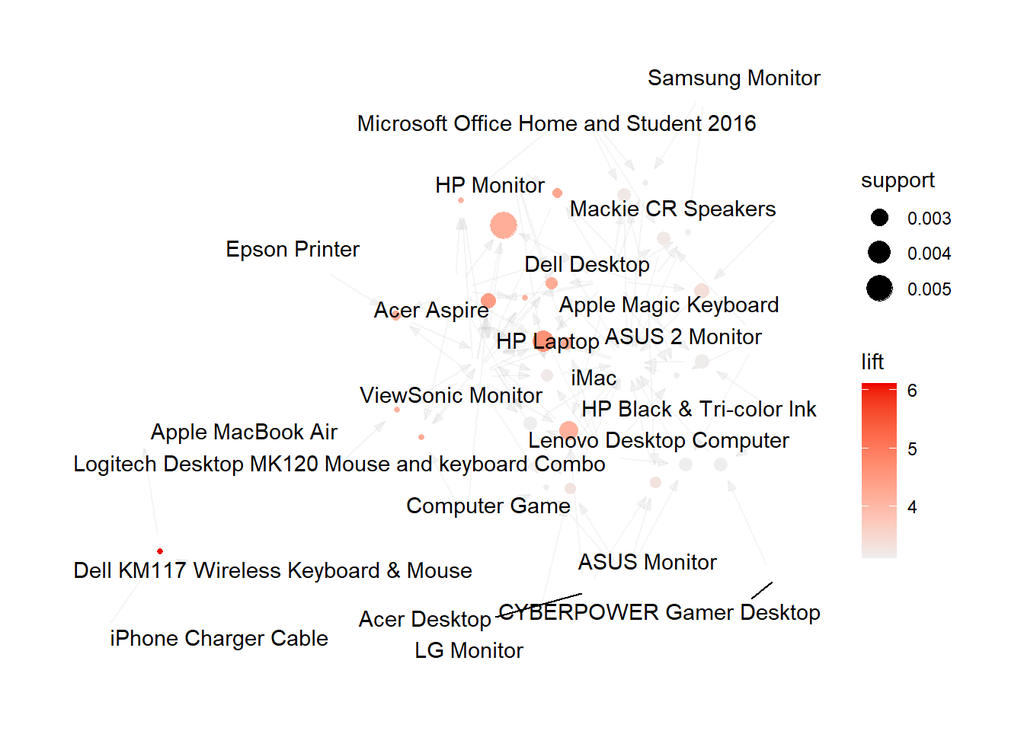

```r
plot(Rules_sup1, method="graph")
```

[figure not shown]

```r
plot(Rules_sup1, method="grouped")
```

INSIGHT # On inspection, we see that two major products iMac, HP Laptops Computers are the consequences of selecting some products throughout the transaction. # We will further investigate iMac and HP Laptops to see how it infleunce buying pattern. #Rules Related to iMac

```r
rules.iMac <- apriori(Electronidex, parameter = list(supp=0.001, conf=0.2), appearance = list(lhs ='iMac', default='rhs'), control = list(verbose=F))
rules.iMac <- sort(rules.iMac, by='confidence', decreasing = FALSE)
summary(rules.iMac)
```

```
## set of 4 rules
##
## rule length distribution (lhs + rhs):sizes
## 2
## 4
##
##    Min. 1st Qu.  Median    Mean 3rd Qu.    Max.
##       2       2       2       2       2       2
##
## summary of quality measures:
##     support          confidence        coverage           lift
##  Min.   :0.05460   Min.   :0.2132   Min.   :0.2561   Min.   :1.204
##  1st Qu.:0.05620   1st Qu.:0.2194   1st Qu.:0.2561   1st Qu.:1.441
##  Median :0.05775   Median :0.2255   Median :0.2561   Median :1.535
##  Mean   :0.06141   Mean   :0.2398   Mean   :0.2561   Mean   :1.466
##  3rd Qu.:0.06296   3rd Qu.:0.2458   3rd Qu.:0.2561   3rd Qu.:1.560
##  Max.   :0.07555   Max.   :0.2950   Max.   :0.2561   Max.   :1.591
##      count
##  Min.   :537.0
##  1st Qu.:552.8
##  Median :568.0
##  Mean   :604.0
##  3rd Qu.:619.2
##  Max.   :743.0
##
## mining info:
##          data ntransactions support confidence
##  Electronidex          9835   0.001        0.2
##                                                                                                                                                     call
##  apriori(data = Electronidex, parameter = list(supp = 0.001, conf = 0.2), appearance = list(lhs = "iMac", default = "rhs"), control = list(verbose = F))
```

```r
inspect(head(rules.iMac,n=10))
```

```
##     lhs       rhs                        support    confidence coverage
## [1] {iMac} => {Dell Desktop}             0.05460092 0.2131798  0.2561261
## [2] {iMac} => {CYBERPOWER Gamer Desktop} 0.05673615 0.2215165  0.2561261
## [3] {iMac} => {Lenovo Desktop Computer}  0.05876970 0.2294561  0.2561261
## [4] {iMac} => {HP Laptop}                0.07554652 0.2949583  0.2561261
##     lift     count
## [1] 1.590762 537
## [2] 1.204320 558
## [3] 1.549932 578
## [4] 1.519599 743
```

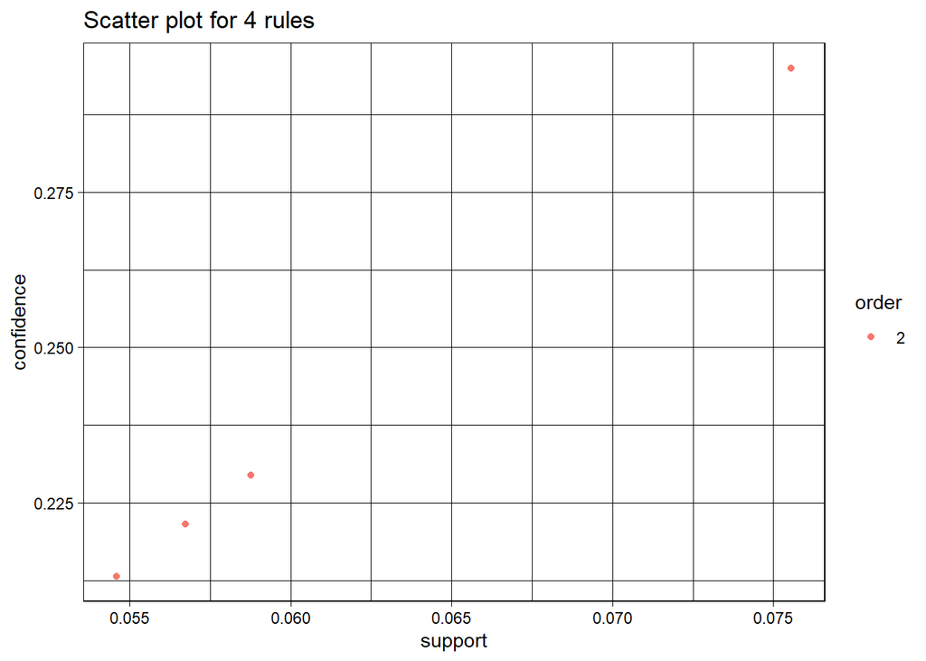

```r
plot(rules.iMac, measure=c("support","confidence"), shading="lift",jitter=0, method='two-key plot')
```

```r
plot(rules.iMac, method = "graph",  engine = "htmlwidget")
```

[interactive chart not shown]

INSIGHTS

we can see that the following items (Dell Desktop, Gamer Desktop, Lenovo Desktop and HP Laptops ) were selected after a customer purchased an iMac.

We can also see that other items purchased after buying an iMac were also other desktop brands for various functionality. This leads use to the conculsion that Electronidex seems not to be for private users but rather for small or medium organization or offices.

#Rules Related to HP Laptops

```r
rules.hpLap <- apriori(Electronidex, parameter = list(supp=0.001, conf=0.2,minlen=2), appearance = list(lhs ='HP Laptop', default='rhs'), control = list(verbose=F))
rules.hpLap <- sort(rules.hpLap, by='confidence', decreasing = FALSE)
summary(rules.hpLap)
```

```
## set of 5 rules
##
## rule length distribution (lhs + rhs):sizes
## 2
## 5
##
##    Min. 1st Qu.  Median    Mean 3rd Qu.    Max.
##       2       2       2       2       2       2
##
## summary of quality measures:
##     support          confidence        coverage           lift
##  Min.   :0.04260   Min.   :0.2195   Min.   :0.1941   Min.   :1.193
##  1st Qu.:0.04494   1st Qu.:0.2315   1st Qu.:0.1941   1st Qu.:1.520
##  Median :0.04616   Median :0.2378   Median :0.1941   Median :1.606
##  Mean   :0.05145   Mean   :0.2651   Mean   :0.1941   Mean   :1.658
##  3rd Qu.:0.04799   3rd Qu.:0.2472   3rd Qu.:0.1941   3rd Qu.:1.728
##  Max.   :0.07555   Max.   :0.3892   Max.   :0.1941   Max.   :2.241
##      count
##  Min.   :419
##  1st Qu.:442
##  Median :454
##  Mean   :506
##  3rd Qu.:472
##  Max.   :743
##
## mining info:
##          data ntransactions support confidence
##  Electronidex          9835   0.001        0.2
##                                                                                                                                                                      call
##  apriori(data = Electronidex, parameter = list(supp = 0.001, conf = 0.2, minlen = 2), appearance = list(lhs = "HP Laptop", default = "rhs"), control = list(verbose = F))
```

```r
inspect(head(rules.hpLap, n=10))
```

```
##     lhs            rhs                        support    confidence coverage
## [1] {HP Laptop} => {CYBERPOWER Gamer Desktop} 0.04260295 0.2194866  0.1941027
## [2] {HP Laptop} => {Dell Desktop}             0.04494154 0.2315348  0.1941027
## [3] {HP Laptop} => {Lenovo Desktop Computer}  0.04616167 0.2378208  0.1941027
## [4] {HP Laptop} => {ViewSonic Monitor}        0.04799187 0.2472499  0.1941027
## [5] {HP Laptop} => {iMac}                     0.07554652 0.3892090  0.1941027
##     lift     count
## [1] 1.193284 419
## [2] 1.727728 442
## [3] 1.606434 454
## [4] 2.241200 472
## [5] 1.519599 743
```

```r
plot(rules.hpLap, method = "graph",  engine = "htmlwidget")
```

[interactive chart not shown]

INSIGHTS

We can observe that customers who bought an HP laptop also bought some Desktops as similar to those who bought an iMac.

We could also see that the number of customers who bought an iMac after buying an HP Laptop is exactly the same as those who bought an iMac before buying an HP Laptop.

#Rules Related to CYBERPOWER Gamer Desktop

```r
rules.CYBERPOWERGamerDesktop <- apriori(Electronidex, parameter = list(supp=0.001, conf=0.2,minlen=2), appearance = list(lhs ='CYBERPOWER Gamer Desktop', default='rhs'), control = list(verbose=F))
rules.CYBERPOWERGamerDesktop<- sort(rules.CYBERPOWERGamerDesktop, by='confidence', decreasing = FALSE)
summary(rules.CYBERPOWERGamerDesktop)
```

```
## set of 3 rules
##
## rule length distribution (lhs + rhs):sizes
## 2
## 3
##
##    Min. 1st Qu.  Median    Mean 3rd Qu.    Max.
##       2       2       2       2       2       2
##
## summary of quality measures:
##     support          confidence        coverage           lift
##  Min.   :0.03833   Min.   :0.2084   Min.   :0.1839   Min.   :1.193
##  1st Qu.:0.04047   1st Qu.:0.2200   1st Qu.:0.1839   1st Qu.:1.194
##  Median :0.04260   Median :0.2316   Median :0.1839   Median :1.195
##  Mean   :0.04589   Mean   :0.2495   Mean   :0.1839   Mean   :1.198
##  3rd Qu.:0.04967   3rd Qu.:0.2700   3rd Qu.:0.1839   3rd Qu.:1.200
##  Max.   :0.05674   Max.   :0.3085   Max.   :0.1839   Max.   :1.204
##      count
##  Min.   :377.0
##  1st Qu.:398.0
##  Median :419.0
##  Mean   :451.3
##  3rd Qu.:488.5
##  Max.   :558.0
##
## mining info:
##          data ntransactions support confidence
##  Electronidex          9835   0.001        0.2
##                                                                                                                                                                                     call
##  apriori(data = Electronidex, parameter = list(supp = 0.001, conf = 0.2, minlen = 2), appearance = list(lhs = "CYBERPOWER Gamer Desktop", default = "rhs"), control = list(verbose = F))
```

```r
inspect(head(rules.CYBERPOWERGamerDesktop, n=5))
```

```
##     lhs                           rhs             support    confidence
## [1] {CYBERPOWER Gamer Desktop} => {Apple Earpods} 0.03833249 0.2084024
## [2] {CYBERPOWER Gamer Desktop} => {HP Laptop}     0.04260295 0.2316197
## [3] {CYBERPOWER Gamer Desktop} => {iMac}          0.05673615 0.3084577
##     coverage  lift     count
## [1] 0.1839349 1.195124 377
## [2] 0.1839349 1.193284 419
## [3] 0.1839349 1.204320 558
```

```r
plot(rules.CYBERPOWERGamerDesktop, method = "graph",  engine = "htmlwidget")
```

[interactive chart not shown]

INSIGHT We could see few transaction with observation of buying CYBERPower Gamer Desktop and Laptop

#Rules Related to Apple Earpods

```r
rules.AppleEarpods <- apriori(Electronidex, parameter = list(supp=0.001, conf=0.2,minlen=2), appearance = list(lhs ='Apple Earpods', default='rhs'), control = list(verbose=F))
rules.AppleEarpods<- sort(rules.AppleEarpods, by='confidence', decreasing = FALSE)
summary(rules.AppleEarpods)
```

```
## set of 2 rules
##
## rule length distribution (lhs + rhs):sizes
## 2
## 2
##
##    Min. 1st Qu.  Median    Mean 3rd Qu.    Max.
##       2       2       2       2       2       2
##
## summary of quality measures:
##     support          confidence        coverage           lift
##  Min.   :0.03833   Min.   :0.2198   Min.   :0.1744   Min.   :0.9015
##  1st Qu.:0.03882   1st Qu.:0.2226   1st Qu.:0.1744   1st Qu.:0.9749
##  Median :0.03930   Median :0.2254   Median :0.1744   Median :1.0483
##  Mean   :0.03930   Mean   :0.2254   Mean   :0.1744   Mean   :1.0483
##  3rd Qu.:0.03978   3rd Qu.:0.2281   3rd Qu.:0.1744   3rd Qu.:1.1217
##  Max.   :0.04026   Max.   :0.2309   Max.   :0.1744   Max.   :1.1951
##      count
##  Min.   :377.0
##  1st Qu.:381.8
##  Median :386.5
##  Mean   :386.5
##  3rd Qu.:391.2
##  Max.   :396.0
##
## mining info:
##          data ntransactions support confidence
##  Electronidex          9835   0.001        0.2
##                                                                                                                                                                          call
##  apriori(data = Electronidex, parameter = list(supp = 0.001, conf = 0.2, minlen = 2), appearance = list(lhs = "Apple Earpods", default = "rhs"), control = list(verbose = F))
```

```r
inspect(head(rules.AppleEarpods, n=10))
```

```
##     lhs                rhs                        support    confidence
## [1] {Apple Earpods} => {CYBERPOWER Gamer Desktop} 0.03833249 0.2198251
## [2] {Apple Earpods} => {iMac}                     0.04026436 0.2309038
##     coverage  lift      count
## [1] 0.1743772 1.1951242 377
## [2] 0.1743772 0.9015239 396
```

```r
plot(rules.AppleEarpods, method = "graph",  engine = "htmlwidget")
```

[interactive chart not shown]

#Rules Related to Apple MacBook Air

```r
rules.AppleMacBookAir <- apriori(Electronidex, parameter = list(supp=0.005, conf=0.09,minlen=2), appearance = list(lhs ='Apple MacBook Air', default='rhs'), control = list(verbose=F))
rules.AppleMacBookAir<- sort(rules.AppleMacBookAir, by='confidence', decreasing = FALSE)
summary(rules.AppleMacBookAir)
```

```
## set of 9 rules
##
## rule length distribution (lhs + rhs):sizes
## 2
## 9
##
##    Min. 1st Qu.  Median    Mean 3rd Qu.    Max.
##       2       2       2       2       2       2
##
## summary of quality measures:
##     support          confidence        coverage           lift
##  Min.   :0.01403   Min.   :0.0902   Min.   :0.1556   Min.   :0.6931
##  1st Qu.:0.01596   1st Qu.:0.1026   1st Qu.:0.1556   1st Qu.:0.7462
##  Median :0.02288   Median :0.1471   Median :0.1556   Median :0.8422
##  Mean   :0.02134   Mean   :0.1372   Mean   :0.1556   Mean   :0.9201
##  3rd Qu.:0.02410   3rd Qu.:0.1549   3rd Qu.:0.1556   3rd Qu.:1.1057
##  Max.   :0.02999   Max.   :0.1928   Max.   :0.1556   Max.   :1.3306
##      count
##  Min.   :138.0
##  1st Qu.:157.0
##  Median :225.0
##  Mean   :209.9
##  3rd Qu.:237.0
##  Max.   :295.0
##
## mining info:
##          data ntransactions support confidence
##  Electronidex          9835   0.005       0.09
##                                                                                                                                                                               call
##  apriori(data = Electronidex, parameter = list(supp = 0.005, conf = 0.09, minlen = 2), appearance = list(lhs = "Apple MacBook Air", default = "rhs"), control = list(verbose = F))
```

```r
inspect(head(rules.AppleMacBookAir, n=10))
```

```
##     lhs                    rhs                                                support confidence  coverage      lift count
## [1] {Apple MacBook Air} => {Samsung Monitor}                               0.01403152 0.09019608 0.1555669 0.9426976   138
## [2] {Apple MacBook Air} => {Dell Desktop}                                  0.01555669 0.10000000 0.1555669 0.7462064   153
## [3] {Apple MacBook Air} => {Lenovo Desktop Computer}                       0.01596340 0.10261438 0.1555669 0.6931404   157
## [4] {Apple MacBook Air} => {Microsoft Wireless Desktop Keyboard and Mouse} 0.01698017 0.10915033 0.1555669 1.1078364   167
## [5] {Apple MacBook Air} => {Apple MacBook Pro}                             0.02287748 0.14705882 0.1555669 1.3305644   225
## [6] {Apple MacBook Air} => {CYBERPOWER Gamer Desktop}                      0.02409761 0.15490196 0.1555669 0.8421563   237
## [7] {Apple MacBook Air} => {HP Laptop}                                     0.02409761 0.15490196 0.1555669 0.7980413   237
## [8] {Apple MacBook Air} => {iMac}                                          0.02846975 0.18300654 0.1555669 0.7145174   280
## [9] {Apple MacBook Air} => {Apple Earpods}                                 0.02999492 0.19281046 0.1555669 1.1057090   295
```

```r
plot(rules.AppleMacBookAir, method = "graph",  engine = "htmlwidget")
```

[interactive chart not shown]

Conclusion

#Patterns and Relationships #We could see from our analysis that customers of Electronidex buy an iMac, HP Laptop and other Desktops the most.

#The pattern of purchase of these product shows that Electronidex customers are either a small or a medium scale organization.

# BENEFIT OF BLACKWELL SELLING ELECTRONIDEX PRODUCTS.

#Will it be beneficial if Blackwell sells Electronidex products? Yes. If Blackwell chooses to sell an iMac or an HP laptop, there are likelihood that it will benefit Blackwell in terms of sales. Other product might as well increase sales for example the Desktops sold by Electronidex, as we have seen high patronage of Desktop by Electronidex customers.

# Should Blackwell Acquire Electronidex?

#YES.Blackwell should acquires Electronidex. The Transaction data shows that Blackwell and Electronidex sells similar products.

#The data suggests that acquiring Electronidex could boost up sales in other product category where Blackwell is under-performing like the PCs and Laptops.

#RECOMMENDATION

#I reccommend that if Blackwell eventually acquires Electronidex, A cross selling of products should be done to better market Blackwell original products. It is also important that blackwell provide product recommendation for purchased products to also help in promoting sales for less purchased products.